# project - Study on the birth rate in the Bay Area (milestone)

## Project Memo

Recently, census results in the US and in China indicate that both countries are likely to start shrinking in population much sooner than they thought.[1]

The sustainable development of a country is inseparable from a steady stream of young people. According to my social life experience, I think from a macro perspective, whether people are willing to have more children largely depends on the overall social and economic development level[2], relevant welfare policies and regional culture. But from a micro perspective, I think there are some dominant (such as household income,…) or recessive factors (living environment, education level of parents,…)[3]that will also affect the willingness of people. I want to explore and uncover this relationship.

Before I bring up some questions, I will define a variable/ factor that I want to explore. I am not sure about what this variable should be at this time. But I think the variable can represent some parents’ (who are in the age of giving birth to a child) willing to give birth to a child at a certain time. So, the variable can be the number of kids in a household who are younger than some ages. I just call the variable the birth rate here.

With the variable identified, I think I can explore several questions, > How different factors (household income, education level of parents, parents’ working hours, environmental factors) affect the birth rate? (regression) > For people of different races or ethnicities, will the effect of the above factors change? [can do some equity analysis] > If the factors above can only explain a part of variation of birth rate, what kind of data or skills do we need to import to increase the regression accuracy. For example, how to quantify some policies to encourage fertility. [Optional]

I will use the Public Use Microdata Sample (PUMS) and CalEnviroScreen as my base dataset. From PUMS, I can find the related variables to identify the birthrate and also some factors affecting the birth rate. From CalEnviroScreen, I can find some environmental factors.

[1] https://www.bbc.com/news/world-57112631 [2] Yin, Xiao‑Cui, and Chi-Wei Su. “House Prices and China’s Birth Rate: A Note.” Asian Economics Letters 2.2 (2021): 22334. [3] Kearney, Melissa Schettini, Phillip B. Levine, and Luke W. Pardue. The Puzzle of Falling US Birth Rates Since the Great Recession. No. w29286. National Bureau of Economic Research, 2021.

## Main body

At this stage, I mainly focus on ACS data (2019/acs/acs5). I found two different variables that can reflect the birth rate. They are “The proportion of young children (under 5) in Bay Area” (`group(B01001)`) and Fertility rate in the past 1 year(`B13002_001E`). Two multiple regression models are built to explore the significant influencing factors.

# The Proportion of young children (under 5) in Bay Area

[interactive chart not shown]

Explore related features

1. Income
- Median household income in the past 12 months) `B19013_001E`: Estimate!!Median household income in the past 12 months (in 2019 inflation-adjusted dollars)
- Percentage of household income over $100,000 `B19001_001E`, `B19001_014E`, `B19001_015E`, `B19001_016E`, `B19001_017E`
- Individual income in the past 12 months `B06010_001E`
- Percentage of low household income in the past 12 months (only for householder 25~44)  
  Here, low household income means less than $50,000
- Percentage of below 100 percent of poverty level in the past 12 months (only for women 15~50)
2. Education attainment
- The percentage of population 25 years and over with college degrees (or more)
3. Features in CES 4.0 data

Features: `CES 4.0 Score`, `Ozone`, `PM2.5`, `Drinking Water`, `Lead`, `Traffic`, `Low Birth Weight`, `Education`, `Poverty`, `Housing Burden`, `Unemployment`

4. Concatenate all features (from ACS, calenviroscreen40)

Conduct a correlation analysis

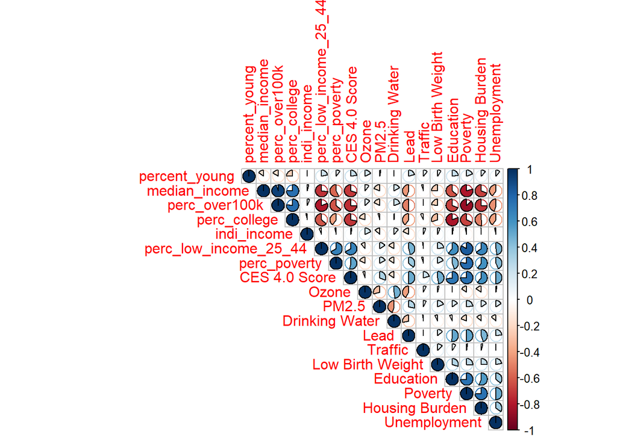

```
##
## Call:
## lm(formula = percent_young ~ median_income + perc_over100k +
##     perc_college + indi_income + perc_low_income_25_44 + perc_poverty +
##     `CES 4.0 Score` + Ozone + PM2.5 + `Drinking Water` + Lead +
##     Traffic + `Low Birth Weight` + Education + Poverty + `Housing Burden` +
##     Unemployment, data = df)
##
## Residuals:
##     Min      1Q  Median      3Q     Max
## -6.3928 -1.4304 -0.1556  1.3676 11.1819
##
## Coefficients:
##                         Estimate Std. Error t value Pr(>|t|)
## (Intercept)           -1.332e+00  1.255e+00  -1.062  0.28855
## median_income         -1.771e-08  3.771e-06  -0.005  0.99625
## perc_over100k          1.918e-02  1.183e-02   1.622  0.10500
## perc_college          -3.509e-01  6.787e-01  -0.517  0.60517
## indi_income           -1.808e-05  3.720e-05  -0.486  0.62706
## perc_low_income_25_44  2.381e+00  7.165e-01   3.324  0.00091 ***
## perc_poverty          -1.466e-02  1.095e-02  -1.339  0.18080
## `CES 4.0 Score`        1.880e-02  9.329e-03   2.016  0.04400 *
## Ozone                  1.462e+02  1.673e+01   8.740  < 2e-16 ***
## PM2.5                 -7.192e-02  1.087e-01  -0.662  0.50828
## `Drinking Water`      -1.215e-03  5.640e-04  -2.154  0.03138 *
## Lead                   2.576e-02  3.613e-03   7.129 1.59e-12 ***
## Traffic                1.757e-04  6.935e-05   2.533  0.01140 *
## `Low Birth Weight`    -2.010e-02  3.874e-02  -0.519  0.60386
## Education             -4.037e-03  1.161e-02  -0.348  0.72806
## Poverty                2.170e-02  1.248e-02   1.738  0.08236 .
## `Housing Burden`      -2.052e-02  1.251e-02  -1.640  0.10113
## Unemployment          -3.688e-02  2.496e-02  -1.477  0.13979
## ---
## Signif. codes:  0 '***' 0.001 '**' 0.01 '*' 0.05 '.' 0.1 ' ' 1
##
## Residual standard error: 2.062 on 1466 degrees of freedom
## Multiple R-squared:  0.1457, Adjusted R-squared:  0.1358
## F-statistic: 14.71 on 17 and 1466 DF,  p-value: < 2.2e-16
```

# Fertility rate in the past 1 year

WOMEN 15 TO 50 YEARS WHO HAD A BIRTH IN THE PAST 12 MONTHS  
`B13002_001E`, `B13002_002E`

[interactive chart not shown]

Same features to first

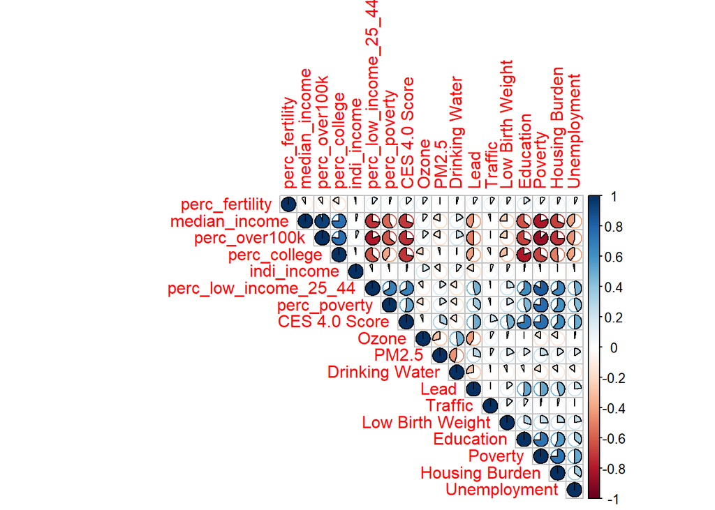

```
##
## Call:
## lm(formula = perc_fertility ~ median_income + perc_over100k +
##     perc_college + indi_income + perc_low_income_25_44 + perc_poverty +
##     `CES 4.0 Score` + Ozone + PM2.5 + `Drinking Water` + Lead +
##     Traffic + `Low Birth Weight` + Education + Poverty + `Housing Burden` +
##     Unemployment, data = df)
##
## Residuals:
##    Min     1Q Median     3Q    Max
## -5.889 -2.091 -0.343  1.696 12.399
##
## Coefficients:
##                         Estimate Std. Error t value Pr(>|t|)
## (Intercept)            1.906e+00  1.751e+00   1.088  0.27675
## median_income         -2.080e-06  5.264e-06  -0.395  0.69274
## perc_over100k          1.435e-02  1.651e-02   0.869  0.38496
## perc_college          -7.532e-01  9.474e-01  -0.795  0.42674
## indi_income           -9.807e-05  5.193e-05  -1.889  0.05913 .
## perc_low_income_25_44  2.209e+00  1.000e+00   2.209  0.02736 *
## perc_poverty          -8.276e-03  1.529e-02  -0.541  0.58834
## `CES 4.0 Score`        5.568e-03  1.302e-02   0.428  0.66901
## Ozone                  6.276e+01  2.335e+01   2.688  0.00727 **
## PM2.5                 -6.923e-02  1.517e-01  -0.456  0.64826
## `Drinking Water`       2.935e-04  7.873e-04   0.373  0.70934
## Lead                   9.986e-03  5.044e-03   1.980  0.04789 *
## Traffic                2.517e-04  9.680e-05   2.600  0.00941 **
## `Low Birth Weight`     4.542e-02  5.407e-02   0.840  0.40103
## Education              2.338e-02  1.621e-02   1.443  0.14924
## Poverty               -1.311e-02  1.743e-02  -0.753  0.45183
## `Housing Burden`      -9.234e-03  1.746e-02  -0.529  0.59699
## Unemployment           3.910e-03  3.485e-02   0.112  0.91068
## ---
## Signif. codes:  0 '***' 0.001 '**' 0.01 '*' 0.05 '.' 0.1 ' ' 1
##
## Residual standard error: 2.879 on 1466 degrees of freedom
## Multiple R-squared:  0.04897,    Adjusted R-squared:  0.03795
## F-statistic: 4.441 on 17 and 1466 DF,  p-value: 4.389e-09
```